# R code for Figure 3 - figure supplement 1 - comparative analysis of defined cell types across species

Xiao Xu (xxu@rockefeller.edu)

June 2018

Xu X, Stoyanova EI, Lemiesz A, Xing J, Mash DC, Heintz N (2018). Species and Cell-Type Properties of Classically Defined Human and Rodent Neurons and Glia.

Specifically, this workflow will generate the figures related to clustering, PCA, and analysis of SI ranks of mouse, human, and rat samples for Figure 3 - figure supplement 1.

Load libraries and functions:

```r
# source custom functions
source("functions.R")
# libraries for gene expression analysis
library(DESeq2)
# libraries for heatmaps and plotting
library(RColorBrewer)
library(gplots)
library(pheatmap)
library(gridExtra)
# for data manipulation
library(plyr)
# work in the tidyverse
library(tidyverse)
library(reshape2)
```

## Clustering analysis

### Import counts

Read in normalized counts from Figure 3 and redefine metadata.

```r
rld <- read_rds("../data_clean/figure_3_main_mm_hg_rn_ortho_norm_rld.RDS")
rld_table <- assay(rld)
meta <- tibble(
  Sample = colnames(rld_table),
  Species = c(rep("mouse", 15), rep("human", 10), rep("rat", 12)),
  Cell_type = gsub("^.*_", "", colnames(rld_table))
)
```

### Hierarchical clustering

Specifiy colors for heatmap:

```r
# specify color palette
hmcol <- colorRampPalette( rev(brewer.pal(9, "RdYlBu")) )(100)
# extend color range to avoid out of bound values showing up as white
hmcol2 <- c(
  hmcol,
  rep(tail(hmcol, n = 1), 40)
  )
# colors for samples
cell_cols <- c(granule = "green", purkinje = "red", basket = "orange",
                astrocyte = "blue", oligo = "cyan", opc = "skyblue")
ann_colors <- list(
  Species = c(human = "olivedrab2", mouse = "pink", rat = "orchid3"),
  Cell_type = cell_cols
)
```

Clustering based on all genes:

```r
distsRL <- dist( t(rld_table) )
hc <- hclust(distsRL)
# center by subracting row mean
mat <- rld_table - rowMeans(rld_table)
```

Plot heatmap.

```r
# save to pdf
pdf("../figures/figure_3_s1_heatmap_spcies_cell_type_var_all.pdf",
    width = 11, height = 8.5)
hm <- pheatmap(
  mat,
  cluster_cols = hc,
  show_rownames = FALSE, show_colnames = FALSE,
  breaks = seq(-5, 9, length = 141),
  col = hmcol2,
  annotation_col = meta %>%
    column_to_rownames("Sample") %>%
    as.data.frame(),
  annotation_colors = ann_colors
)
```

```
Setting row names on a tibble is deprecated.
```

```r
dev.off()
```

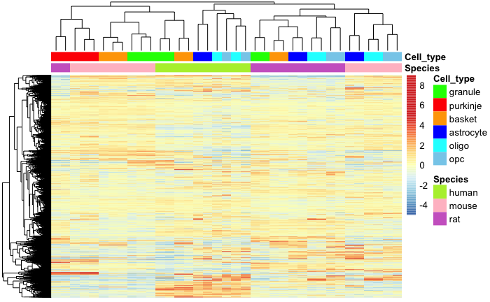

```r
# and display in this file
hm
```

## principal components analysis

Calculate principal components:

```r
pca <- calcPCA(rld,
               intgroup = c('Species', 'Cell_type'),
               ntop = 250, npcs = 8)
# reorder cell types
pca$Cell_type <- factor(pca$Cell_type,
                        levels = c("granule", "purkinje", "basket",
                                   "astrocyte", "oligo", "opc"))
```

Examine contribution of different principal components.

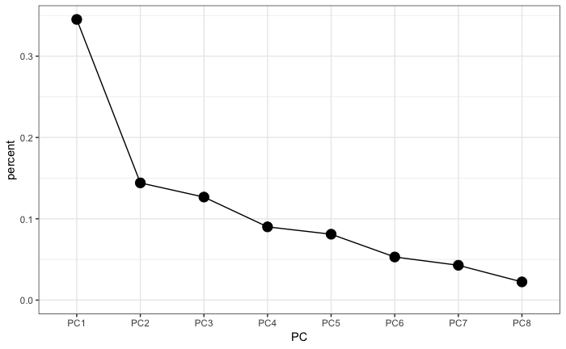

```r
plotPCImportance(pca)
ggsaveToPdf("../figures/figure_3_s1_pca_importance.pdf")
```

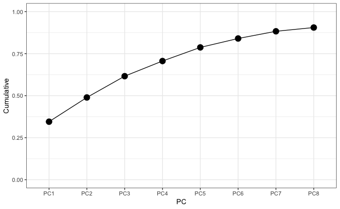

```r
plotPCCumImportance(pca)
ggsaveToPdf("../figures/figure_3_s1_pca_cum_importance.pdf")
```

```r
# get some summary statistics
pvar <- attributes(pca)$percentVar[1:8]
sum(pvar) # percentage contribution to variability of PC1-8
```

```
[1] 0.9054013
```

```r
sum(pvar[c(1, 3)])  # percentage contribtuion of PC1 and 3 - cell type
```

```
[1] 0.4719034
```

```r
sum(pvar[c(2, 6, 8)])  # percentage contribution of PC 2, 6, and 8 - species
```

```
[1] 0.2195454
```

Plot PC1 and 2 together:

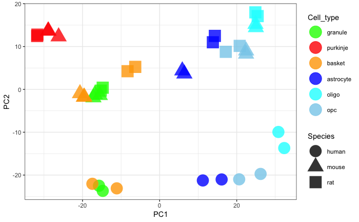

```r
ggplot(pca, mapping = aes(x = PC1, y = PC2)) +
  geom_point(aes(shape = Species, color = Cell_type),
             size = 8, alpha = 0.8) +
  scale_color_manual(values = cell_cols) +
  theme_bw()
ggsaveToPdf("../figures/figure_3_s1_pca_pc1_vs_pc2.pdf", w = 6, h = 4)
```

```r
plotPCsCustom <- function(pca, pc) {
  ggplot(pca, mapping = aes_string(x = "PC1", y = pc)) +
    geom_point(aes(shape = Species, color = Cell_type),
               size = 2, alpha = 0.8) +
    scale_color_manual(values = cell_cols) +
    theme_bw() +
    theme(legend.position = "none")
}
all_plots <- lapply(paste("PC", seq(from = 3, to = 8, by = 1), sep = ""),
                    plotPCsCustom, pca = pca)
# arrange plots in grid and save to pdf
saveToPdf("../figures/figure_3_s1_pca_pc1_vs_pcs3-8.pdf", w = 9, h = 6)
pca_grid <- grid.arrange(all_plots[[1]], all_plots[[2]], all_plots[[3]], all_plots[[4]],
                         all_plots[[5]], all_plots[[6]], ncol = 3)
dev.off()
```

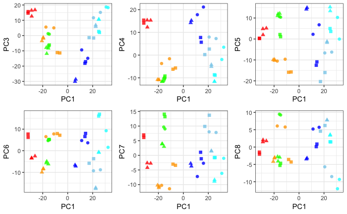

```r
# display plot here
grid.arrange(pca_grid)
```

# Correlation analysis

## Calculate correlations

Create table of pairwise correlations and do a bunch of data wrangling to get it into the right format

```r
pairwise_cor <- cor(rld_table) %>%                     # get pairwise correlation
  as.data.frame() %>%
  rownames_to_column("Sample") %>%
  left_join(meta, by = "Sample") %>%                   # merge with metadata
  melt(id = c("Sample", "Species", "Cell_type")) %>%   # melt data
  filter(Species == "mouse") %>%                       # use mouse as reference species
  left_join(meta, by = c("variable" = "Sample"), suffix = c("_from", "_to")) %>%   # get to species meta
  # only keep correlation if same species, different cell types
  # or different species, same cell type
  filter((Species_from == Species_to & Cell_type_from != Cell_type_to) |
           (Species_from != Species_to & Cell_type_from == Cell_type_to)) %>%
  # define type of comparison
  mutate(Comp = ifelse(Species_to == "mouse", "mouse", Cell_type_to)) %>%
  # relevel for plotting
  mutate(Comp = factor(Comp, levels = c("granule", "purkinje", "basket",
              "astrocyte", "oligo", "opc", "mouse")))
```

```
Column `variable`/`Sample` joining factor and character vector, coercing into character vector
```

## Plot

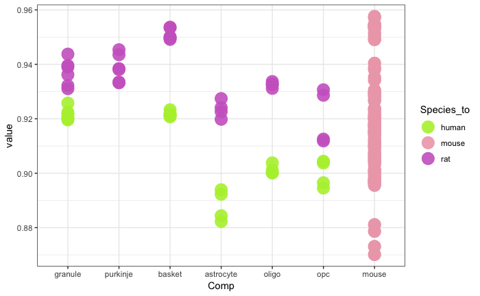

```r
# colors for plotting
species_col<-c(human="olivedrab2", mouse="pink2", rat="orchid3")
# dot plot
ggplot(pairwise_cor, aes(x = Comp, y = value)) +
  geom_point(aes(color = Species_to), size = 6, alpha = 0.9) +
  scale_color_manual(values = species_col) +
  theme_bw()
ggsaveToPdf("../figures/figure_3_s1_cor_speices_cell_type.pdf")
```

# Specificity index comparison

Compute specificity index for each species on orthologous genes only.

Read in counts and define metadata. Calculate with and without Purkinje samples. Remove mouse and rat Purkinje samples so that all species have the same group of cell types.

```r
counts <- read_tsv("../data/merge_mm_hg_rn_ortho_all_wg_counts.txt")
counts_sub <- counts %>%
  select(-contains("purkinje"))
meta <- tibble(
  Sample = colnames(counts)[-1],
  Species = c(rep("mouse", 15), rep("human", 10), rep("rat", 12)),
  Cell_type = gsub("^.*_", "", colnames(counts)[-1])
)
meta_sub <- meta %>%
  filter(Cell_type != "purkinje")
```

Normalize counts by length using FPKM (RPKM) calculation.

```r
# define length files for each species
length_files <- tibble(
  Species = c("mouse", "rat", "human"),
  Lengths = c("../data/ref/ensembl_ortho_mouse_gene_longest.txt",
              "../data/ref/ensembl_ortho_rat_gene_longest_to_mouse.txt",
              "../data/ref/ensembl_ortho_human_gene_longest_to_mouse.txt")
)
rpkms <- lapply(
  c("mouse", "rat"),
  function(species) getRPKMBySpecies(species, length_files, counts, meta) )
names(rpkms) <- c("mouse", "rat")
rpkms_sub <- lapply(
  unique(meta$Species),
  function(species) getRPKMBySpecies(species, length_files, counts_sub, meta_sub)
  )
names(rpkms_sub) <- unique(meta$Species)
```

Calculate SI for each species on server using parallel processing.

```r
writeSI <- function(species, rpkm_list, meta,
                    filebase = "../output/figure_3_s1_si_ortho_") {
   set.seed(1)
   si_table <- siWithReps(rpkm_list[[species]] %>% as.data.frame(),
                          meta %>% filter(Species == species) %>% pull(Cell_type),
                          bottom = 0, reps = TRUE, iterations = 1000,
                          parallel = TRUE, cores = 32)
   write_tsv(si_table %>%
               as.data.frame() %>%
               rownames_to_column("Gene"),
             paste(filebase, species, ".txt", sep = ""))
   return(NULL)
}

# with purkinje
lapply(c("mouse", "rat"), writeSI, rpkm_list = rpkms,
       meta = meta, filebase = "../output/figure_3_s1_si_ortho_")

# without purkinje
lapply(unique(meta$Species), writeSI, rpkm_list = rpkms_sub,
       meta = meta_sub, filebase = "../output/figure_3_s1_si_ortho_wo_purk_")
```

Import SI rankings

```r
si_wo_purk <- list(
  mouse = read_tsv("../output/figure_3_s1_si_ortho_wo_purk_mouse.txt"),
  rat = read_tsv("../output/figure_3_s1_si_ortho_wo_purk_rat.txt"),
  human = read_tsv("../output/figure_3_s1_si_ortho_wo_purk_human.txt")
)
si_w_purk <- list(
  mouse = read_tsv("../output/figure_3_s1_si_ortho_mouse.txt"),
  rat = read_tsv("../output/figure_3_s1_si_ortho_rat.txt")
)
```

Get ranks of mouse top SI genes in other species and plot heatmap

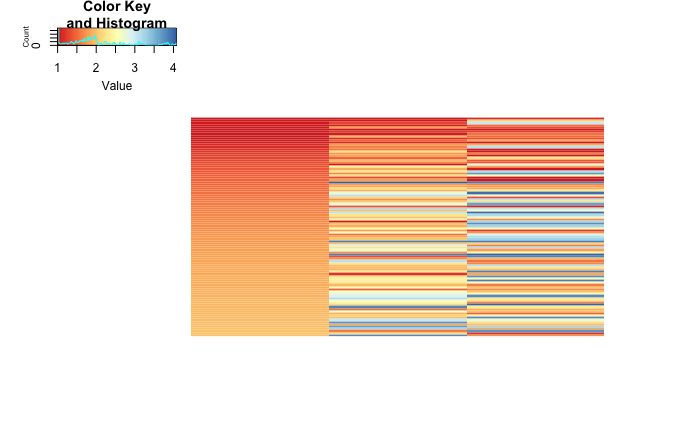

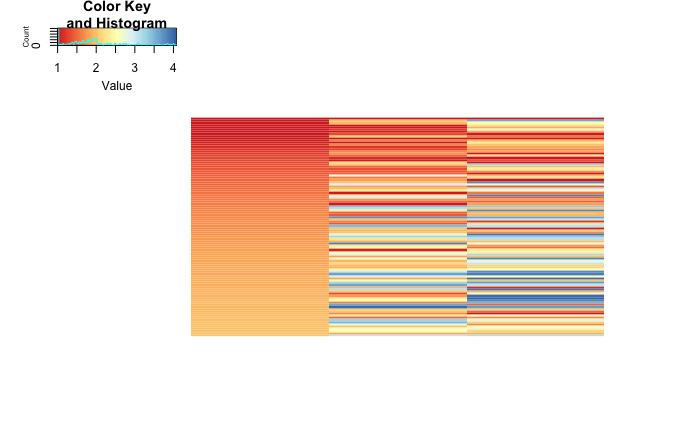

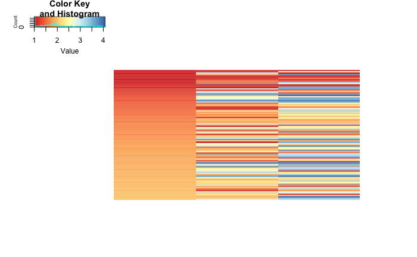

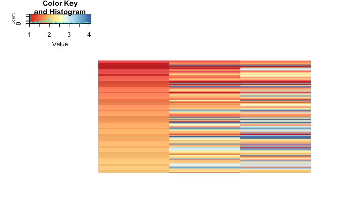

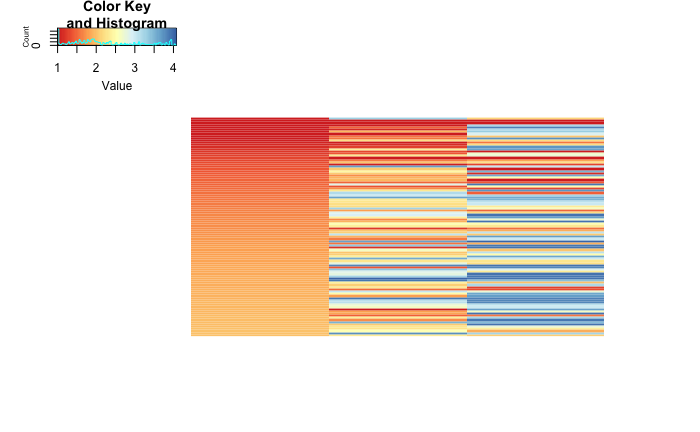

```r
plotAndReturnRanks <- function(cell_type, si_all, species, hm_cols, breaks) {
  # for top 100 mouse genes, get si ranks in rat and human
  ranks <- sapply(species,
                  function(x) getRank(siGetTopN(si_all[["mouse"]], cell_type, 100),
                                      si_all[[x]], cell_type))
  ranks_log <- log(ranks, base = 10)

  #####   plot heatmap   #####

  saveToPdf( paste("../figures/figure_3_s1_heatmap_si_", cell_type, ".pdf", sep = "") )
  hm <- heatmap.2(
    ranks_log,
    col = hm_cols, breaks = breaks,
    dendrogram = "none", margins = c(6, 6),
    labCol = FALSE, labRow = FALSE,
    Rowv = FALSE, Colv = FALSE,
    scale = "none",trace = "none"
  )
  dev.off()

  # and display in this file
  eval(hm$call)

  # return melted ranks
  return( melt(ranks) %>%
            select(-Var1, Species = Var2, Rank = value) %>%
            mutate(Cell_type = cell_type) )
}
# set colors for heatmaps
breaks <- seq(from = 1, to = log(12000, base = 10), length.out = 101)
hm_cols <- colorRampPalette( brewer.pal(9, "RdYlBu") )(100)
mranks <- lapply(c("granule", "basket", "astrocyte", "oligo", "opc"),
                 plotAndReturnRanks,
                 si_all = si_wo_purk,
                 species = c("mouse", "rat", "human"),
                 hm_cols = hm_cols,
                 breaks = breaks)
```

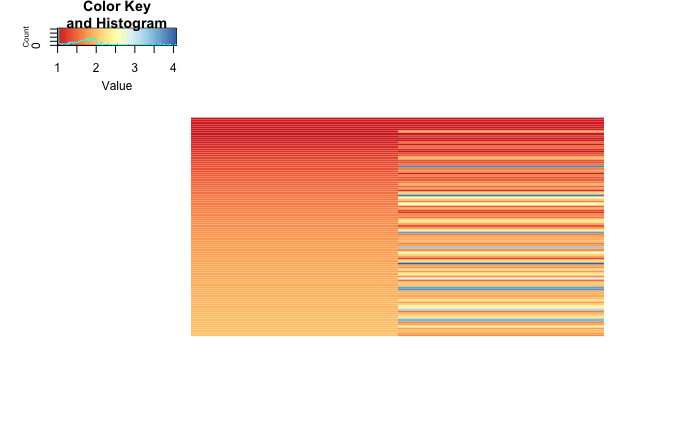

```r
mranks[["purkinje"]] <- plotAndReturnRanks("purkinje", si_w_purk,
                                           c("mouse", "rat"), hm_cols, breaks)
```

## Boxplot of rankings

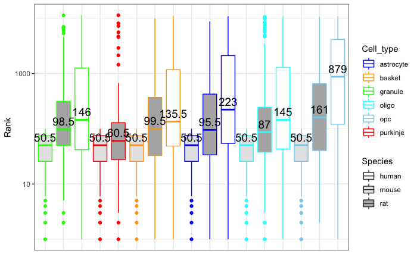

```r
# set order for plot
order_conds <- c("granule_mouse", "granule_rat", "granule_human",
                 "purkinje_mouse", "purkinje_rat",
                 "basket_mouse", "basket_rat", "basket_human",
                 "astrocyte_mouse", "astrocyte_rat", "astrocyte_human",
                 "oligo_mouse", "oligo_rat", "oligo_human",
                 "opc_mouse", "opc_rat", "opc_human")
# format data frame for plotting
ranks_all <- mranks %>%
  bind_rows %>%
  mutate(Condition = paste(Cell_type, Species, sep = "_")) %>%
  mutate(Condition = factor(Condition, order_conds))
# get median rank values for plotting
rank_meds <- ranks_all %>%
  group_by(Condition) %>%
  summarise(med = median(Rank))
# set colors
cell_cols <- c(granule = "green", purkinje = "red", basket = "orange",
              astrocyte = "blue", oligo = "cyan", opc = "skyblue")
# plot
ggplot(ranks_all, aes(x = Condition, y = Rank)) +
  geom_boxplot(aes(color = Cell_type, fill = Species)) +
  scale_y_log10() +
  scale_color_manual(values = cell_cols) +
  scale_fill_manual(values = c("white", "grey90", "grey70")) +
  geom_text(data = rank_meds, aes(x = Condition, y = med, label = med),
            size = 5, vjust = -0.5) +
  theme_bw() +
  theme(axis.title.x = element_blank(),
        axis.text.x = element_blank(),
        axis.ticks.x = element_blank())
# save plot
ggsaveToPdf("../figures/figure_3_s1_box_si.pdf")
```